# Megan_Beaudry Coding exercise

#*LOADING AND CHECKING DATA*  
#We want to load the dslabs package  
#Also now loading tidyverse and skimr packages  
#Load the gapminder data set

```r
library(dslabs)
library(tidyverse)
library(skimr)
data("gapminder")
```

#Use the help() function to see what the data contains

```r
help(gapminder)
```

```
## starting httpd help server ... done
```

#str - displays basic strucutual info.

```r
str(gapminder)
```

```
## 'data.frame':    10545 obs. of  9 variables:
##  $ country         : Factor w/ 185 levels "Albania","Algeria",..: 1 2 3 4 5 6 7 8 9 10 ...
##  $ year            : int  1960 1960 1960 1960 1960 1960 1960 1960 1960 1960 ...
##  $ infant_mortality: num  115.4 148.2 208 NA 59.9 ...
##  $ life_expectancy : num  62.9 47.5 36 63 65.4 ...
##  $ fertility       : num  6.19 7.65 7.32 4.43 3.11 4.55 4.82 3.45 2.7 5.57 ...
##  $ population      : num  1636054 11124892 5270844 54681 20619075 ...
##  $ gdp             : num  NA 1.38e+10 NA NA 1.08e+11 ...
##  $ continent       : Factor w/ 5 levels "Africa","Americas",..: 4 1 1 2 2 3 2 5 4 3 ...
##  $ region          : Factor w/ 22 levels "Australia and New Zealand",..: 19 11 10 2 15 21 2 1 22 21 ...
```

##The nine variables of this dataset are: country, year, infant_mortality, life_expectany, fertility, population, gdp, continent, region

#summary - statistical summaries of selected data. Type of data shown depends on class

```r
summary(gapminder)
```

```
##                 country           year      infant_mortality
##  Albania            :   57   Min.   :1960   Min.   :  1.50
##  Algeria            :   57   1st Qu.:1974   1st Qu.: 16.00
##  Angola             :   57   Median :1988   Median : 41.50
##  Antigua and Barbuda:   57   Mean   :1988   Mean   : 55.31
##  Argentina          :   57   3rd Qu.:2002   3rd Qu.: 85.10
##  Armenia            :   57   Max.   :2016   Max.   :276.90
##  (Other)            :10203                  NA's   :1453
##  life_expectancy   fertility       population             gdp
##  Min.   :13.20   Min.   :0.840   Min.   :3.124e+04   Min.   :4.040e+07
##  1st Qu.:57.50   1st Qu.:2.200   1st Qu.:1.333e+06   1st Qu.:1.846e+09
##  Median :67.54   Median :3.750   Median :5.009e+06   Median :7.794e+09
##  Mean   :64.81   Mean   :4.084   Mean   :2.701e+07   Mean   :1.480e+11
##  3rd Qu.:73.00   3rd Qu.:6.000   3rd Qu.:1.523e+07   3rd Qu.:5.540e+10
##  Max.   :83.90   Max.   :9.220   Max.   :1.376e+09   Max.   :1.174e+13
##                  NA's   :187     NA's   :185         NA's   :2972
##     continent                region
##  Africa  :2907   Western Asia   :1026
##  Americas:2052   Eastern Africa : 912
##  Asia    :2679   Western Africa : 912
##  Europe  :2223   Caribbean      : 741
##  Oceania : 684   South America  : 684
##                  Southern Europe: 684
##                  (Other)        :5586
```

#glimpse - shows data frame info again (like str structural info) only now in a form easier to read

```r
glimpse(gapminder)
```

```
## Observations: 10,545
## Variables: 9
## $ country          <fct> Albania, Algeria, Angola, Antigua and Barbuda...
## $ year             <int> 1960, 1960, 1960, 1960, 1960, 1960, 1960, 196...
## $ infant_mortality <dbl> 115.40, 148.20, 208.00, NA, 59.87, NA, NA, 20...
## $ life_expectancy  <dbl> 62.87, 47.50, 35.98, 62.97, 65.39, 66.86, 65....
## $ fertility        <dbl> 6.19, 7.65, 7.32, 4.43, 3.11, 4.55, 4.82, 3.4...
## $ population       <dbl> 1636054, 11124892, 5270844, 54681, 20619075, ...
## $ gdp              <dbl> NA, 13828152297, NA, NA, 108322326649, NA, NA...
## $ continent        <fct> Europe, Africa, Africa, Americas, Americas, A...
## $ region           <fct> Southern Europe, Northern Africa, Middle Afri...
```

#skim - shows summary statistics (like summary) only now with brief histograms, details on missing data for each variable, and as much other information as possible in a concise form.

```r
skim(gapminder)
```

|  | variable | type | stat | level | value | formatted |
| --- | --- | --- | --- | --- | --- | --- |
| 1 | country | factor | missing | .all | 0.000000e+00 | 0 |
| 2 | country | factor | complete | .all | 1.054500e+04 | 10545 |
| 3 | country | factor | n | .all | 1.054500e+04 | 10545 |
| 4 | country | factor | n_unique | .all | 1.850000e+02 | 185 |
| 5 | country | factor | top_counts | Albania | 5.700000e+01 | Alb: 57 |
| 6 | country | factor | top_counts | Algeria | 5.700000e+01 | Alg: 57 |
| 7 | country | factor | top_counts | Angola | 5.700000e+01 | Ang: 57 |
| 8 | country | factor | top_counts | Antigua and Barbuda | 5.700000e+01 | Ant: 57 |
| 9 | country | factor | top_counts | Argentina | 5.700000e+01 | Arg: 57 |
| 10 | country | factor | top_counts | Armenia | 5.700000e+01 | Arm: 57 |

[output cut: 286 more lines]

#class - what type of fuction is gapminder

```r
class(gapminder)
```

```
## [1] "data.frame"
```

#*PROCESSING DATA*  
#Here the workflow diverges into a Tidyverse Exercise and a base R exercise. Tidyverse exercises are shown first

#*Tidyverse code and plotting*  
#For tidyverse package use, we start a pipeline for gapminder data with %>% (“then”)  
#We then filter () the data for only those data whose country is Africa  
#then select() only the variables infant_mortality, life_expectancy, population, and country to remain  
#plotting with country by color reveals many African countries. We also see that 226 rows are omitted from the plot due to missing values  
#We see the same negative correlation between infant mortality and life expectancy here as we do below with base R code

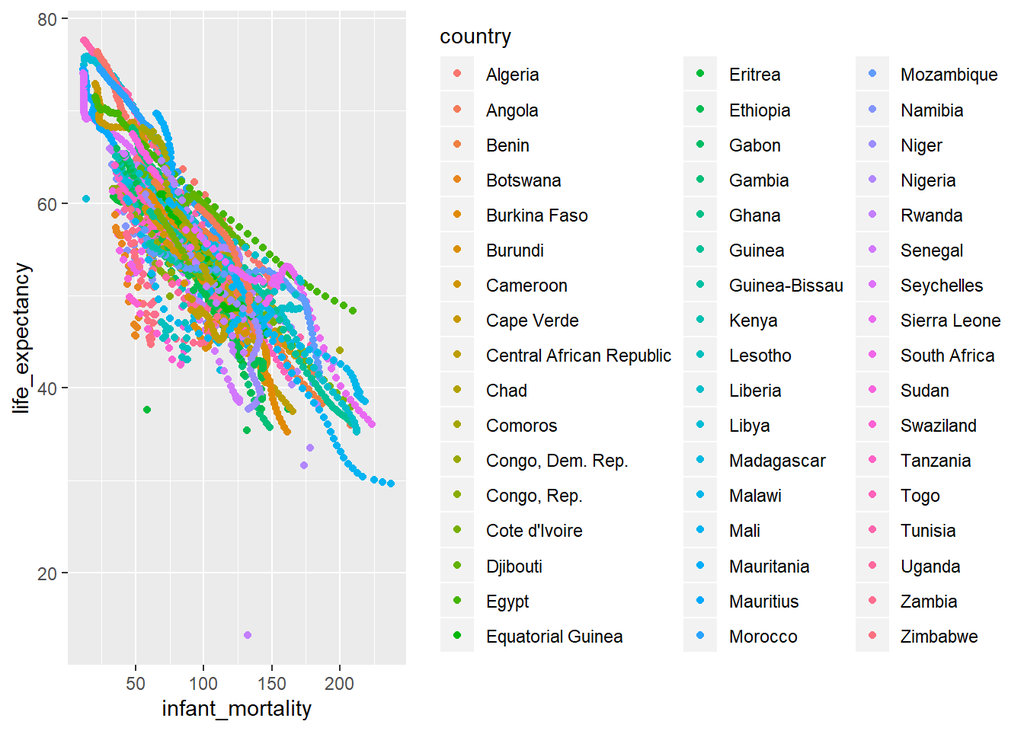

```r
gapminder %>%
  filter(continent == "Africa") %>%
  select(infant_mortality, life_expectancy, population, country) %>%
  ggplot() + geom_point(aes(infant_mortality, life_expectancy, col= country))
```

#Repeat for plot of population versus life expectancy  
#In this case, 51 omissions occur due to no population variable value  
#Here, we see a similar result with slightly positive trending between these variables as we did in base R code below

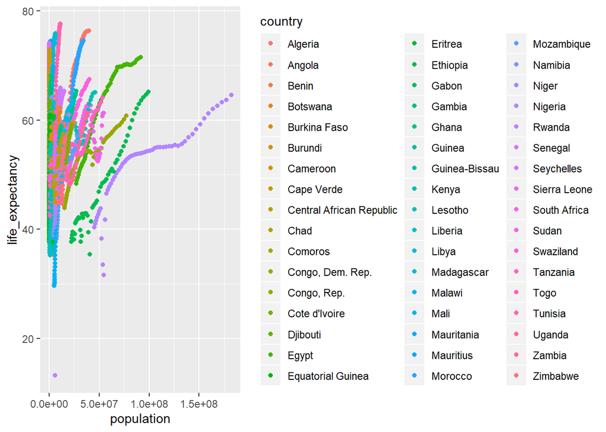

```r
gapminder %>%
  filter(continent == "Africa") %>%
  select(infant_mortality, life_expectancy, population, country) %>%
  ggplot() + geom_point(aes(population, life_expectancy, col= country))
```

#For our final Tidyverse plot using ggplot(), we will pull out only Africa AND year 2000 data for a life_expectancy as a function of infant mortality

#We will plot our points and use the geom_smooth() function with method() set to “lm” (linear model) to show our best fit line.

#The best fit line helps visualize the negative correlation we saw accross all years in African countries in just the year 2000 as well. The shadowed region around the line is the standard error range of the linear model best fit, which is boolean se = TRUE as a default for ggplot.

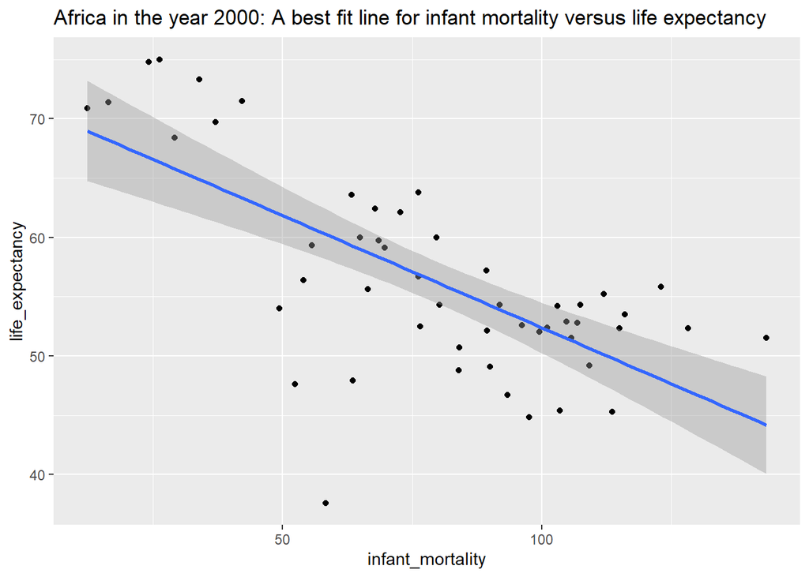

```r
gapminder %>%
  filter(continent == "Africa", year == 2000) %>%
  select(infant_mortality, life_expectancy, population, country) %>%
  ggplot(aes(infant_mortality, life_expectancy)) + geom_point() +geom_smooth(method = "lm") + labs(title= "Africa in the year 2000: A best fit line for infant mortality versus life expectancy")
```

#*Base R code with original plots from coding exercise 1*

#For base R, <- right of the chosen variable name  
. All african counties are accessed through the dataset gapminder by using the variable. The accessor $ is used to access specific variables (i.e., continent) within  
#Again in base R, We then pull out the african counties by using a logical vector (i.e., ==) to determine if the variable content is listed as “Africa”

```r
africadata <- gapminder$continent == "Africa"
```

#str - basic information on the variable defined above #summary - statistical summaries of selected data

```r
str(africadata)
```

```
##  logi [1:10545] FALSE TRUE TRUE FALSE FALSE FALSE ...
```

```r
summary(africadata)
```

```
##    Mode   FALSE    TRUE
## logical    7638    2907
```

##the results from this code chunk indicated that we have 2907 arguments that are “true” out of a total of 10545. You can see this is the same result as using filter and select in tidyverse.

#For base R, we want to define two new variables: (1) Infant_LifeExpec_Africa ~ which includes infant_mortality and life_expectency and (2) Pop_LifeExp_Africa ~ includes population and life_expectancy

#First, lets pull out just the infant_mortality data from africa #In order to do so, we call the variable infant_mortality_africa #Then, we need to access the infant mortality data within gapminder using the $ accessor and applying the logical vector (ie., []) africadata. This makes it so we only pull the infant mortality data from africa

```r
infant_mortality_africa <- gapminder$infant_mortality[africadata]
```

#Lets apply the same logic to pull out the life expectancy data

```r
life_expectency_africa <- gapminder$life_expectancy[africadata]
```

#now we have to seperate variables that we want to combine to make Infant_LifeExpec_Africa ##when want to combine two variables we use a dataframe #We need to define the pieces of the dataframe by using equal signs followed by the variables we created earlier. None of this is necessary with tidyverse.

```r
Infant_LifeExpec_Africa <- data.frame(infant_mortality = infant_mortality_africa, life_expectancy = life_expectency_africa)
```

#Now we need to repeat the process with a different set of variables to create Pop_LifeExp_Africa ~ includes population and life_expectancy

```r
Population_africa <- gapminder$population[africadata]
life_expectency_africa <- gapminder$life_expectancy[africadata]
```

#create the dataframe #remember to name the dataframe using <- #then define parts of the dataframe using = and the dataset

```r
Pop_LifeExp_Africa <- data.frame(population = Population_africa, life_expectency = life_expectency_africa)
```

#Now lets check out these new dataframes we made using the str and summary function

```r
str(Pop_LifeExp_Africa)
```

```
## 'data.frame':    2907 obs. of  2 variables:
##  $ population     : num  11124892 5270844 2431620 524029 4829291 ...
##  $ life_expectency: num  47.5 36 38.3 50.3 35.2 ...
```

```r
str(Infant_LifeExpec_Africa)
```

```
## 'data.frame':    2907 obs. of  2 variables:
##  $ infant_mortality: num  148 208 187 116 161 ...
##  $ life_expectancy : num  47.5 36 38.3 50.3 35.2 ...
```

```r
summary(Pop_LifeExp_Africa)
```

```
##    population        life_expectency
##  Min.   :    41538   Min.   :13.20
##  1st Qu.:  1605232   1st Qu.:48.23
##  Median :  5570982   Median :53.98
##  Mean   : 12235961   Mean   :54.38
##  3rd Qu.: 13888152   3rd Qu.:60.10
##  Max.   :182201962   Max.   :77.60
##  NA's   :51
```

```r
summary(Infant_LifeExpec_Africa)
```

```
##  infant_mortality life_expectancy
##  Min.   : 11.40   Min.   :13.20
##  1st Qu.: 62.20   1st Qu.:48.23
##  Median : 93.40   Median :53.98
##  Mean   : 95.12   Mean   :54.38
##  3rd Qu.:124.70   3rd Qu.:60.10
##  Max.   :237.40   Max.   :77.60
##  NA's   :226
```

#We know have two new variables with 2907 rows #the variable Pop_LifeExp_Africa contains populations and life_expectancy data #the variable Infant_LifeExpec_Africa contains infant mortaility and life_expectancy data

#*PLOTTING*

#plot life expectancy vs infant mortality for all african countries using the dataframe you previously made

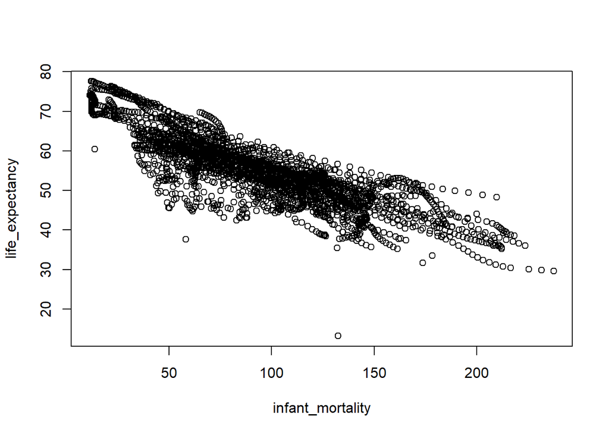

```r
plot(Infant_LifeExpec_Africa)
```

#the plot indicates a negative correlation between the two variables ##Countires with increased infant mortality show a decrease in life expectancy

#Plot population vs life expectancy for all african countries #we need to convert population to a log10 function first. In order to do so we should created a new variable which holds the population data in log10 form

```r
logten_pop_africa <- log10(Population_africa)
```

#we now need to create a new datafram with the population at log10 scale #list the variable you want on the x-asix first (i.e., log10 population)

```r
log10_pop_life_expec_africa <- data.frame(population = logten_pop_africa, life_expectancy = life_expectency_africa)
```

#now we can plot it

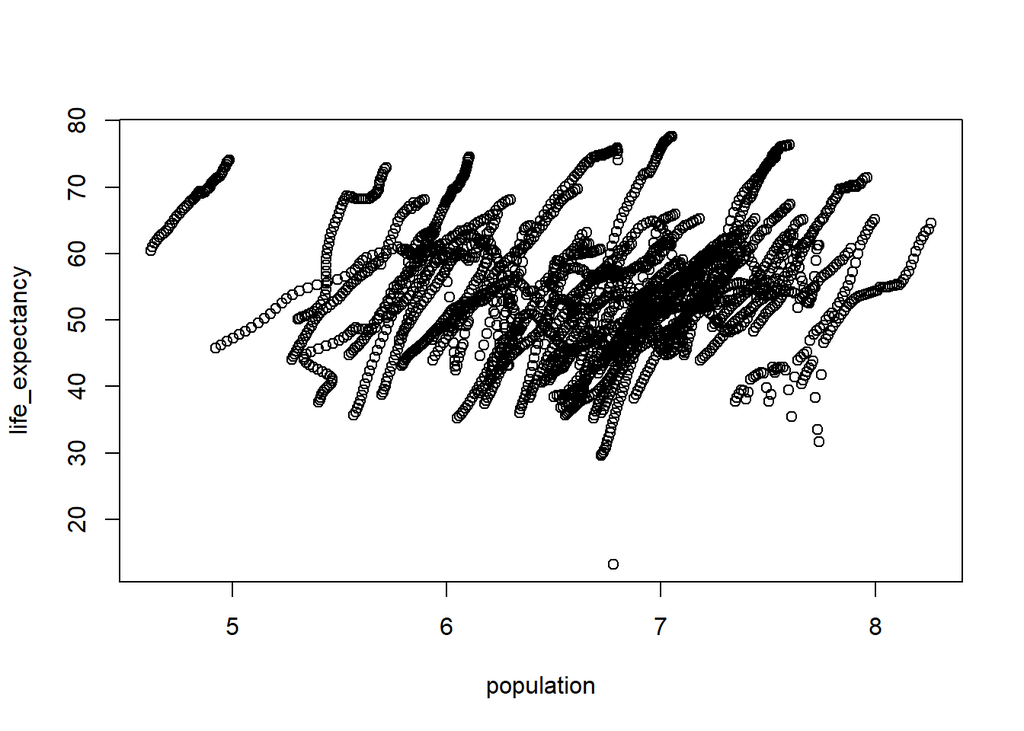

```r
plot(log10_pop_life_expec_africa)
```

#this plot shows streaks of data that appear to go together. By looking at this streaks i believe that they show the different countries in africa. They also seem to move in a positive trend.

#*MORE DATA PROCESSING* #which years have missing infant mortality data #In order to determine this i am creating a variable for the NA values #i will used the is comand to pull the na values

```r
na_index <- is.na(infant_mortality_africa)
```

#now i am applying the na_index to the gapminder year data to see which ones are na

```r
gapminder$year[na_index]
```

```
##   [1] 1960 1960 1960 1960 1960 1960 1960 1960 1960 1960 1960 1960 1960 1960
##  [15] 1960 1960 1960 1960 1960 1960 1960 1960 1960 1960 1960 1960 1960 1960
##  [29] 1960 1960 1960 1960 1960 1960 1960 1960 1960 1960 1960 1960 1960 1960
##  [43] 1960 1960 1960 1960 1960 1960 1960 1960 1960 1960 1960 1960 1960 1961
##  [57] 1961 1961 1961 1961 1961 1961 1961 1961 1961 1961 1961 1961 1961 1961
##  [71] 1961 1961 1961 1961 1961 1961 1961 1961 1961 1961 1961 1961 1961 1961
##  [85] 1961 1961 1961 1961 1961 1961 1961 1961 1961 1961 1961 1961 1961 1961
##  [99] 1961 1961 1961 1961 1961 1961 1961 1961 1962 1962 1962 1962 1962 1962
## [113] 1962 1962 1962 1962 1962 1962 1962 1962 1962 1962 1962 1962 1962 1962
## [127] 1962 1962 1962 1962 1962 1962 1962 1962 1962 1963 1963 1963 1963 1963
## [141] 1963 1963 1963 1963 1963 1963 1963 1963 1963 1963 1963 1963 1963 1963
## [155] 1963 1963 1963 1963 1964 1964 1964 1964 1964 1964 1964 1964 1964 1964
## [169] 1964 1964 1965 1965 1965 1965 1965 1975 1975 1975 1975 1975 1975 1975
## [183] 1975 1975 1975 1975 1975 1975 1975 1975 1975 1975 1975 1975 1975 1975
## [197] 1975 1975 1975 1975 1975 1975 1975 1975 1975 1975 1975 1975 1975 1975
```

[output cut: 46 more lines]

#we now see a list of years where infant mortality data is missing. # some years are repeated. This means that multiple countries are missing those years in Africa

#in order to see the total number of NA values in the variable Na_index, we can use the sum function

```r
sum(na_index)
```

```
## [1] 226
```

#there are 226, which matches what was given in our exercise

```r
 yr2000 <- gapminder$year == 2000
```

#Now we want to use the logical operator & since we want two things to be true (i.e., from africa data AND the year 2000) #We will call this new variable africa2000

```r
africa2000 <- yr2000 & africadata
```

#Now we need to apply this index to all NINE variable in the dataset to pull out the data for the year 2000 in only african countries

```r
year2000 <- gapminder$year[africa2000]
region2000 <- gapminder$region[africa2000]
country2000 <- gapminder$country[africa2000]
infant_mortality2000 <- gapminder$infant_mortality[africa2000]
life_expectency2000 <- gapminder$life_expectancy[africa2000]
fertility2000 <- gapminder$fertility[africa2000]
gdp2000 <- gapminder$gdp[africa2000]
continent2000 <- gapminder$continent[africa2000]
population2000 <- gapminder$population[africa2000]
```

#phew, pulled them all out

#now we need to create a new dataframe using all the new variable names we created above that single out african countries in the year 2000

```r
africa2000_df <- data.frame(year = year2000, region = region2000, country = country2000, infant_mortality = infant_mortality2000, life_expectency = life_expectency2000, fertility = fertility2000, gdp = gdp2000, continent= continent2000, population = population2000)
```

#now check the data using str and summary

```r
str(africa2000_df)
```

```
## 'data.frame':    51 obs. of  9 variables:
##  $ year            : int  2000 2000 2000 2000 2000 2000 2000 2000 2000 2000 ...
##  $ region          : Factor w/ 22 levels "Australia and New Zealand",..: 11 10 20 17 20 5 10 20 10 10 ...
##  $ country         : Factor w/ 185 levels "Albania","Algeria",..: 2 3 18 22 26 27 29 31 32 33 ...
##  $ infant_mortality: num  33.9 128.3 89.3 52.4 96.2 ...
##  $ life_expectency : num  73.3 52.3 57.2 47.6 52.6 46.7 54.3 68.4 45.3 51.5 ...
##  $ fertility       : num  2.51 6.84 5.98 3.41 6.59 7.06 5.62 3.7 5.45 7.35 ...
##  $ gdp             : num  5.48e+10 9.13e+09 2.25e+09 5.63e+09 2.61e+09 ...
##  $ continent       : Factor w/ 5 levels "Africa","Americas",..: 1 1 1 1 1 1 1 1 1 1 ...
##  $ population      : num  31183658 15058638 6949366 1736579 11607944 ...
```

```r
summary(africa2000_df)
```

```
##       year                            region           country
##  Min.   :2000   Eastern Africa           :16   Algeria     : 1
##  1st Qu.:2000   Western Africa           :16   Angola      : 1
##  Median :2000   Middle Africa            : 8   Benin       : 1
##  Mean   :2000   Northern Africa          : 6   Botswana    : 1
##  3rd Qu.:2000   Southern Africa          : 5   Burkina Faso: 1
##  Max.   :2000   Australia and New Zealand: 0   Burundi     : 1
##                 (Other)                  : 0   (Other)     :45
##  infant_mortality life_expectency   fertility          gdp
##  Min.   : 12.30   Min.   :37.60   Min.   :1.990   Min.   :2.019e+08
##  1st Qu.: 60.80   1st Qu.:51.75   1st Qu.:4.150   1st Qu.:1.274e+09
##  Median : 80.30   Median :54.30   Median :5.550   Median :3.238e+09
##  Mean   : 78.93   Mean   :56.36   Mean   :5.156   Mean   :1.155e+10
##  3rd Qu.:103.30   3rd Qu.:60.00   3rd Qu.:5.960   3rd Qu.:8.654e+09
##  Max.   :143.30   Max.   :75.00   Max.   :7.730   Max.   :1.329e+11
##
##     continent    population
##  Africa  :51   Min.   :    81154
##  Americas: 0   1st Qu.:  2304687
##  Asia    : 0   Median :  8799165
##  Europe  : 0   Mean   : 15659800
##  Oceania : 0   3rd Qu.: 17391242
##                Max.   :122876723
##
```

#we have 51 observation and 9 variables

#*MORE PLOTTING* #Now we are going to make the two previous plots again, however only using the data from the year 2000 #first lets plot infant mortality and life expectency in africa for the yr 2000

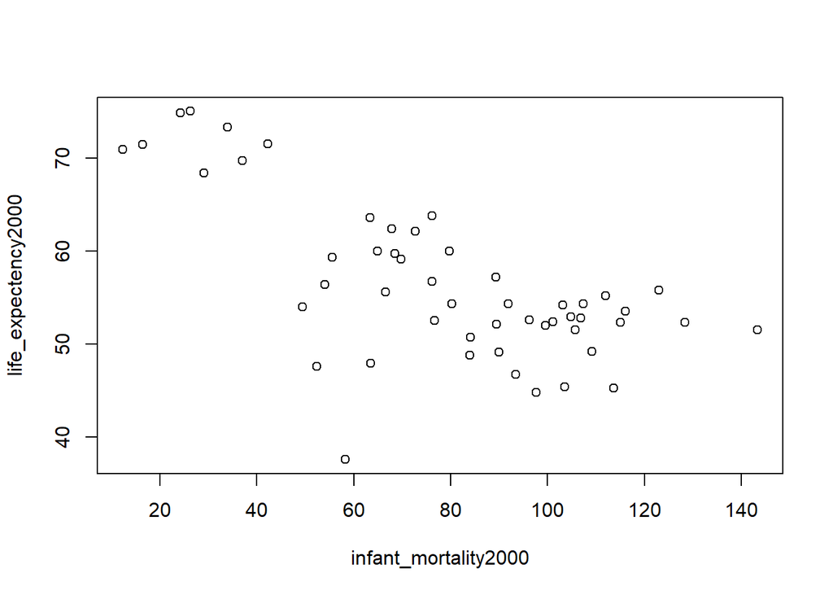

```r
plot(infant_mortality2000, life_expectency2000)
```

#we see a negative correlation

#plot population size and life expectancy for the year 2000 in africa #first define the population to a log10 scale

```r
log10pop_yr2000 <- log10(population2000)
```

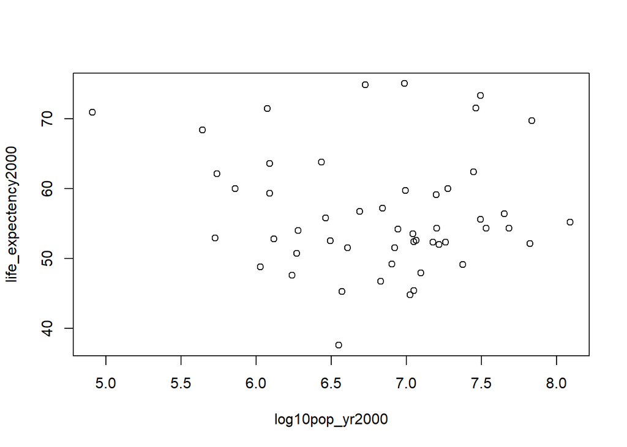

```r
plot(log10pop_yr2000, life_expectency2000)
```

#no noticeable correlation

#A SIMPLE FIT #Use the lm function (linear model function - used to create a simple regression model) and fit life expectancy at the outcome (y variable), and infant mortality as the predictor (x variable) #the summary function gives us various statistics indlucding residuals, coefficents,

```r
lm1 <- lm(life_expectency2000 ~ infant_mortality2000)
summary(lm1)
```

```
##
## Call:
## lm(formula = life_expectency2000 ~ infant_mortality2000)
##
## Residuals:
##      Min       1Q   Median       3Q      Max
## -22.6651  -3.7087   0.9914   4.0408   8.6817
##
## Coefficients:
##                      Estimate Std. Error t value Pr(>|t|)
## (Intercept)          71.29331    2.42611  29.386  < 2e-16 ***
## infant_mortality2000 -0.18916    0.02869  -6.594 2.83e-08 ***
## ---
## Signif. codes:  0 '***' 0.001 '**' 0.01 '*' 0.05 '.' 0.1 ' ' 1
##
## Residual standard error: 6.221 on 49 degrees of freedom
## Multiple R-squared:  0.4701, Adjusted R-squared:  0.4593
## F-statistic: 43.48 on 1 and 49 DF,  p-value: 2.826e-08
```

```r
lm2 <- lm(life_expectency2000 ~ log10pop_yr2000)
summary(lm2)
```

```
##
## Call:
## lm(formula = life_expectency2000 ~ log10pop_yr2000)
##
## Residuals:
##     Min      1Q  Median      3Q     Max
## -19.113  -4.809  -1.554   3.907  18.863
##
## Coefficients:
##                 Estimate Std. Error t value Pr(>|t|)
## (Intercept)       65.324     12.520   5.217 3.65e-06 ***
## log10pop_yr2000   -1.315      1.829  -0.719    0.476
## ---
## Signif. codes:  0 '***' 0.001 '**' 0.01 '*' 0.05 '.' 0.1 ' ' 1
##
## Residual standard error: 8.502 on 49 degrees of freedom
## Multiple R-squared:  0.01044,    Adjusted R-squared:  -0.009755
## F-statistic: 0.517 on 1 and 49 DF,  p-value: 0.4755
```

#P value of 0.4755. A p value this size suggests the variables are not related (i.e., population size does not affect life expectancy)

#we can also visualise this fit line on the scatterplot using the abline function

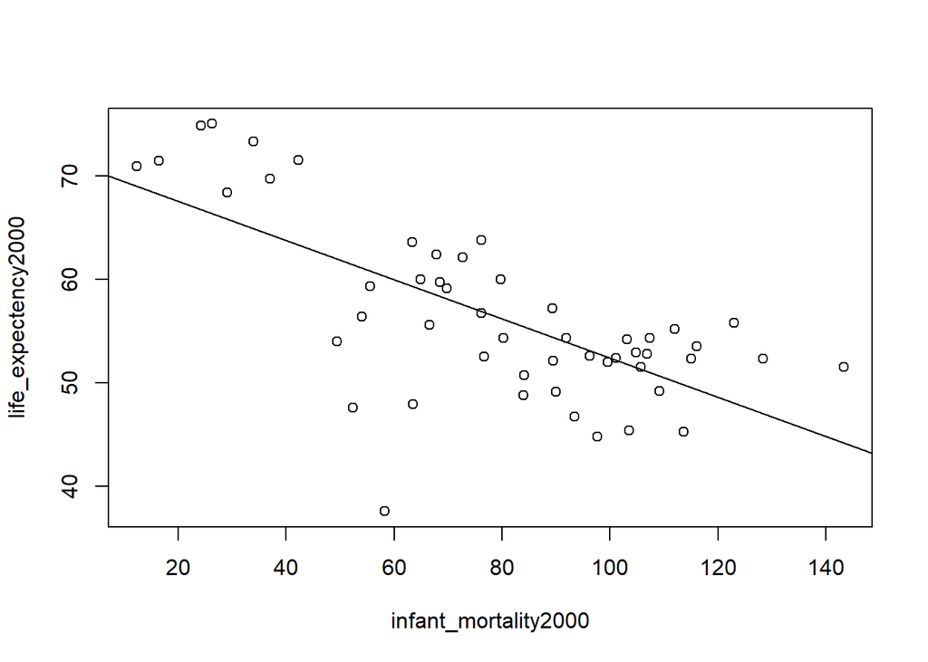

```r
plot(infant_mortality2000, life_expectency2000)
abline(lm1)
```

#this is nice because it resolidifies the conclusions i came to before

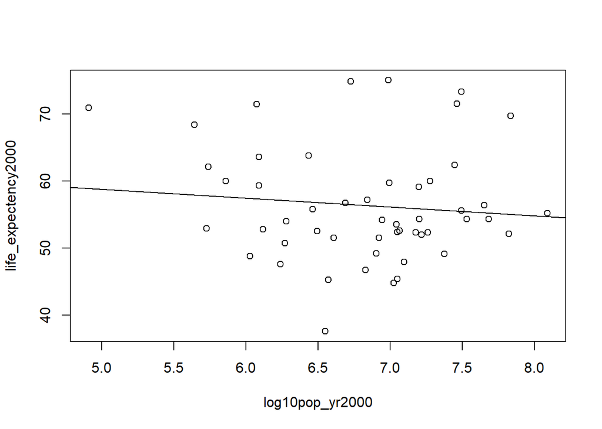

```r
plot(log10pop_yr2000, life_expectency2000)
abline(lm2)
```